# Untitled

ekonomix

25 January 2017

# Executive Summary

We have data from 4 sensors placed on participants bodies and object (belt, forearm, arm and the dumbell); they measure how the different body parts and the dumbell itself are moving as the participant is attempting to lift it.

Participants were asked to lift the dumbell in 5 different ways, 1 correct way and 4 ‘wrong’ ways. Our aim is to distinguish “how well” the exercise is taking place, hence using the sensor data distinguish between these different types of lift.

## load some libraries we are likely to be using

```r
library(caret)
```

```r
library(ggplot2)
```

## Get data - download as csv and load

```r
Urla <- "https://d396qusza40orc.cloudfront.net/predmachlearn/pml-training.csv"
Urlb <- "https://d396qusza40orc.cloudfront.net/predmachlearn/pml-testing.csv"
training <- read.csv(url(Urla), na.strings=c("NA","#DIV/0!",""))
testing <- read.csv(url(Urlb), na.strings=c("NA","#DIV/0!",""))
```

## take a look at the data

```r
dim(training)
```

```
## [1] 19622   160
```

```r
#str(training) # not shown in output
dim(testing)
```

```
## [1]  20 160
```

```r
#str(testing) # not shown in output
```

it looks like the first 7 variables have no predictive value for this exercise

## get rid of variables with many NAs and variables expected to have no predictive value in this case

```r
NA_Count = sapply(1:dim(training)[2],function(x)sum(is.na(training[,x])))
NA_Count
```

```
##   [1]     0     0     0     0     0     0     0     0     0     0     0
##  [12] 19226 19248 19622 19225 19248 19622 19216 19216 19226 19216 19216
##  [23] 19226 19216 19216 19226 19216 19216 19216 19216 19216 19216 19216
##  [34] 19216 19216 19216     0     0     0     0     0     0     0     0
##  [45]     0     0     0     0     0 19216 19216 19216 19216 19216 19216
##  [56] 19216 19216 19216 19216     0     0     0     0     0     0     0
##  [67]     0     0 19294 19296 19227 19293 19296 19227 19216 19216 19216
##  [78] 19216 19216 19216 19216 19216 19216     0     0     0 19221 19218
##  [89] 19622 19220 19217 19622 19216 19216 19221 19216 19216 19221 19216
## [100] 19216 19221     0 19216 19216 19216 19216 19216 19216 19216 19216
## [111] 19216 19216     0     0     0     0     0     0     0     0     0
## [122]     0     0     0 19300 19301 19622 19299 19301 19622 19216 19216
## [133] 19300 19216 19216 19300 19216 19216 19300     0 19216 19216 19216
## [144] 19216 19216 19216 19216 19216 19216 19216     0     0     0     0
## [155]     0     0     0     0     0     0
```

```r
NA_list = which(NA_Count>0)
```

## modify the training and test data sets to remove unnecessary columns and transforming the class into a factor

```r
training_cleaning <- training[,-NA_list]
training_cleaning <- training_cleaning[,-c(1:7)]
training_cleaning$classe = factor(training_cleaning$classe)

inTrain <-createDataPartition(training_cleaning$classe, p=0.60, list=FALSE)
training_clean = training_cleaning[inTrain,]
validation_clean = training_cleaning[-inTrain,]

testing_clean <- testing[,-NA_list]
testing_clean <- testing_clean[,-c(1:7)]


# head(testing_clean) # not shown in output
```

## build models and deciding which works best

## this is a classification problem, and we’ll try random forest and classification tree

These are methods used for supervised learning which means the class we are trying to predict is known.

A decision tree (both of these methods are some form of decision trees) basically takes the whole dataset, then runs through the cariables and picks the one that causes the best split, which means the 2 groups are the most distinct. How this is measured can be specified in the algorithm.

The process of splitting each subset is repeated until the tree has reached a maximum depth, or the benefit of splitting in terms of increased distinctiveness cannot be reached.

The main difference between random forest and a std classification tree is that random forest, as the name suggests, build many trees and combines them, usually by voting. The advantage of random forest is that it is less likely to be influenced by quirks in the data (overfitting issue), however, on large datasets, it can be computationally expensive, and it is harder to explain.

In this case I will crossvalidate the random forest 3 times. Since the dataset is small and here I don;t care about explainability, I expect random forest to perform better.

```r
set.seed(2501)
```

Random Forest

```r
rfFit <- train(classe ~ ., method = "rf", data = training_clean, importance = T, trControl = trainControl(method = "cv", number = 3))
#validation performance
validation_rfpred <- predict(rfFit, newdata=validation_clean)
rf_confusion <-confusionMatrix(validation_rfpred,validation_clean$classe)
rf_confusion
```

```
## Confusion Matrix and Statistics
##
##           Reference
## Prediction    A    B    C    D    E
##          A 2224    6    0    0    0
##          B    6 1506    5    1    0
##          C    0    6 1356   25    2
##          D    0    0    7 1260    9
##          E    2    0    0    0 1431
##
## Overall Statistics
##
##                Accuracy : 0.9912
##                  95% CI : (0.9889, 0.9932)
##     No Information Rate : 0.2845
##     P-Value [Acc > NIR] : < 2.2e-16
##
##                   Kappa : 0.9889
##  Mcnemar's Test P-Value : NA
##
## Statistics by Class:
##
##                      Class: A Class: B Class: C Class: D Class: E
## Sensitivity            0.9964   0.9921   0.9912   0.9798   0.9924
## Specificity            0.9989   0.9981   0.9949   0.9976   0.9997
## Pos Pred Value         0.9973   0.9921   0.9762   0.9875   0.9986
## Neg Pred Value         0.9986   0.9981   0.9981   0.9960   0.9983
## Prevalence             0.2845   0.1935   0.1744   0.1639   0.1838
## Detection Rate         0.2835   0.1919   0.1728   0.1606   0.1824
## Detection Prevalence   0.2842   0.1935   0.1770   0.1626   0.1826
## Balanced Accuracy      0.9977   0.9951   0.9931   0.9887   0.9960
```

```r
#looks good
```

## Random Forest Results look good!

Classification Tree

```r
rpartFit <- train(classe ~ ., method = "rpart", data = training_clean)
#training performance
validation_rpartpred <- predict(rpartFit, newdata=validation_clean)
confusionMatrix(validation_rpartpred,validation_clean$classe)
```

```
## Confusion Matrix and Statistics
##
##           Reference
## Prediction    A    B    C    D    E
##          A 2035  638  625  566  217
##          B   35  517   39  225  181
##          C  158  363  704  495  362
##          D    0    0    0    0    0
##          E    4    0    0    0  682
##
## Overall Statistics
##
##                Accuracy : 0.5019
##                  95% CI : (0.4908, 0.513)
##     No Information Rate : 0.2845
##     P-Value [Acc > NIR] : < 2.2e-16
##
##                   Kappa : 0.349
##  Mcnemar's Test P-Value : NA
##
## Statistics by Class:
##
##                      Class: A Class: B Class: C Class: D Class: E
## Sensitivity            0.9117  0.34058  0.51462   0.0000  0.47295
## Specificity            0.6356  0.92415  0.78728   1.0000  0.99938
## Pos Pred Value         0.4987  0.51856  0.33814      NaN  0.99417
## Neg Pred Value         0.9477  0.85385  0.88480   0.8361  0.89385
## Prevalence             0.2845  0.19347  0.17436   0.1639  0.18379
## Detection Rate         0.2594  0.06589  0.08973   0.0000  0.08692
## Detection Prevalence   0.5201  0.12707  0.26536   0.0000  0.08743
## Balanced Accuracy      0.7736  0.63236  0.65095   0.5000  0.73616
```

```r
#not as good
```

## Regressions trees are nto as good as random forest here.

## Hence Random Forest is Chosen!

## important variables, expected error (1-accuracy) and predictions for test data:

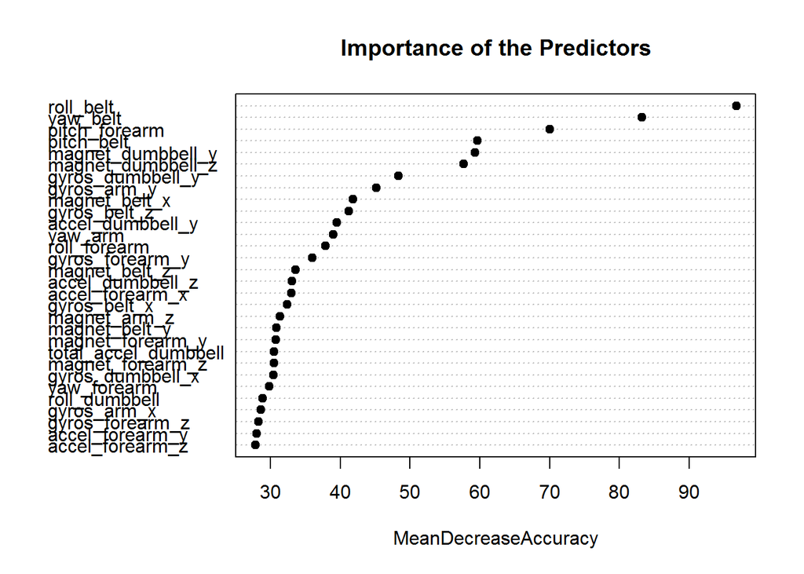

```r
#Important Variables
imp_rf <- varImp(rfFit)$importance
varImpPlot(rfFit$finalModel, sort = TRUE, type = 1, pch = 19, col = 1, cex = 1, main = "Importance of the Predictors")
```

```r
#accuracy and expected error
attributes(rf_confusion)
```

```
## $names
## [1] "positive" "table"    "overall"  "byClass"  "mode"     "dots"
##
## $class
## [1] "confusionMatrix"
```

```r
rf_confusion$overall
```

```
##       Accuracy          Kappa  AccuracyLower  AccuracyUpper   AccuracyNull
##      0.9912057      0.9888768      0.9888833      0.9931513      0.2844762
## AccuracyPValue  McnemarPValue
##      0.0000000            NaN
```

```r
rf_confusion$overall['Accuracy']
```

```
##  Accuracy
## 0.9912057
```

```r
rf_confusion$overall['AccuracyUpper']
```

```
## AccuracyUpper
##     0.9931513
```

```r
rf_confusion$overall['AccuracyLower']
```

```
## AccuracyLower
##     0.9888833
```

```r
testing_rfpred <- predict(rfFit, newdata=testing_clean)
testing_rfpred
```

```
##  [1] B A B A A E D B A A B C B A E E A B B B
## Levels: A B C D E
```

## writing out the predictions

```r
pml_write_files = function(x){
  n = length(x)
  for(i in 1:n){
    filename = paste0("./practical_ml_wk4_",i,".txt")
    write.table(x[i],file=filename,quote=FALSE,row.names=FALSE,col.names=FALSE)
  }
}

pml_write_files(testing_rfpred)

testing_rfpred
```

```
##  [1] B A B A A E D B A A B C B A E E A B B B
## Levels: A B C D E
```